# Homework 10

Solutions for Questions 1 and 2 are included in the combined ZIP. No solution will be provided for Question 3.

Use the RLT package for Questions 1 and 2: `RLT` in R or `rlt` in Python. The node-size parameter is `nmin` in R and `min_samples_leaf` in Python; both stop splitting a node when it contains at most that many observations. The candidate-predictor parameter is `mtry` in both languages. Use ordinary random forests, with reinforcement turned off.

## Question 1: Bias-variance trade-off simulation

Two important tuning parameters of random forests are node size and `mtry`. We have performed some preliminary analysis in class. The goal of this question is to perform a larger simulation study for these two tuning parameters.

Consider a regression model with five jointly normally distributed predictors. Each predictor has mean 0 and variance 1, and the correlation between any two different predictors is 0.3. The response is

$$Y=X_1+X_3+X_5+\varepsilon,
\qquad \varepsilon\sim N(0,1),$$

where the noise is independent of the predictors. Thus the true regression function is $f(\mathbf{x})=x_1+x_3+x_5$.

1. Set up a simulation study with 100 repetitions. Generate 200 test predictor vectors once and keep them fixed. In each repetition, generate 200 new training observations and use the same training data for all tuning settings. Fit 500-tree forests, drawing 200 observations with replacement for each tree. Make the following two comparisons:
   - Fix `mtry` at 3 and vary node size over $1,5,10,20,30$.
   - Fix node size at 10 and vary `mtry` over $1,2,3,4,5$.

   Leave all other fitting parameters at their defaults. Record the predictions at each test point across repetitions. For each setting, estimate the squared bias and variance at each test point, then average them over the 200 test points. Compare predictions with $f(\mathbf{x})$ when estimating bias. Produce two figures, one for each tuning parameter, showing the averaged squared bias and variance. Set a random seed and report it.

```r
library(RLT)
library(MASS)
set.seed(432)
seed_used <- 432
B <- 100
n_train <- 200
n_test <- 200
p <- 5
ntrees <- 500
node_sizes <- c(1, 5, 10, 20, 30)
mtry_values <- c(1, 2, 3, 4, 5)
Sigma <- matrix(0.3, nrow = p, ncol = p)
diag(Sigma) <- 1
X_test <- MASS::mvrnorm(n_test, mu = rep(0, p), Sigma = Sigma)
f_test <- X_test[, 1] + X_test[, 3] + X_test[, 5]
pred_node <- array(NA, dim = c(n_test, B, length(node_sizes)))
pred_mtry <- array(NA, dim = c(n_test, B, length(mtry_values)))
for (b in 1:B) {
  X_train <- MASS::mvrnorm(n_train, mu = rep(0, p),Sigma = Sigma)
  epsilon <- rnorm(n_train, mean = 0, sd = 1)
  Y_train <- X_train[, 1] + X_train[, 3] +  X_train[, 5] + epsilon

  for (j in seq_along(node_sizes)) {
    fit <- RLT(
      x = X_train,
      y = Y_train,
      model = "regression",
      ntrees = 500,
      mtry = 3,
      nmin = node_sizes[j],
      replacement = TRUE,
      resample.prob = 1,
      reinforcement = FALSE,
      importance = FALSE
    )
    pred_node[, b, j] <-
      predict(fit, X_test)$Prediction
  }
  for (j in seq_along(mtry_values)) {
    fit <- RLT(
      x = X_train,
      y = Y_train,
      model = "regression",
      ntrees = 500,
      mtry = mtry_values[j],
      nmin = 10,
      replacement = TRUE,
      resample.prob = 1,
      reinforcement = FALSE,
      importance = FALSE
    )
    pred_mtry[, b, j] <-
      predict(fit, X_test)$Prediction
  }
}
```

[output not shown]

[output cut: 945 more lines]

[output not shown]

```r
calculate_bv <- function(predictions, true_values, settings) {
  results <- data.frame(
    setting = settings,
    squared_bias = NA,
    variance = NA
  )
  for (j in seq_along(settings)) {
    avg_pred <- rowMeans(predictions[, , j])
    results$squared_bias[j] <-
      mean((avg_pred - true_values)^2)
    point_variance <- apply(
      predictions[, , j], 1, var
    )
    results$variance[j] <-
      mean(point_variance * (B - 1) / B)
  }
  return(results)
}

node_results <- calculate_bv(
  pred_node, f_test, node_sizes
)
mtry_results <- calculate_bv(
  pred_mtry, f_test, mtry_values
)
print(node_results)
```

```
  setting squared_bias   variance
1       1    0.2323714 0.10558904
2       5    0.2277522 0.09443073
3      10    0.2442824 0.07746883
4      20    0.3107656 0.06157807
5      30    0.4013427 0.05556503
```

```r
print(mtry_results)
```

```
  setting squared_bias   variance
1       1    0.7533613 0.03770999
2       2    0.3415324 0.05893576
3       3    0.2433062 0.07770833
4       4    0.2051142 0.09480370
5       5    0.1859250 0.10716585
```

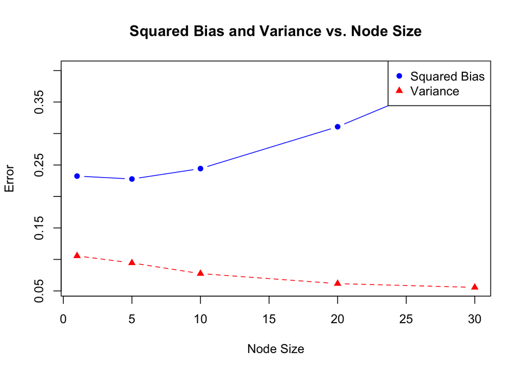

```r
matplot(
  node_results$setting,
  node_results[, c("squared_bias", "variance")],
  type = "b",
  pch = c(16, 17),
  col = c("blue", "red"),
  xlab = "Node Size",
  ylab = "Error",
  main = "Squared Bias and Variance vs. Node Size"
)
legend(
  "topright",
  legend = c("Squared Bias", "Variance"),
  col = c("blue", "red"),
  pch = c(16, 17),
)
```

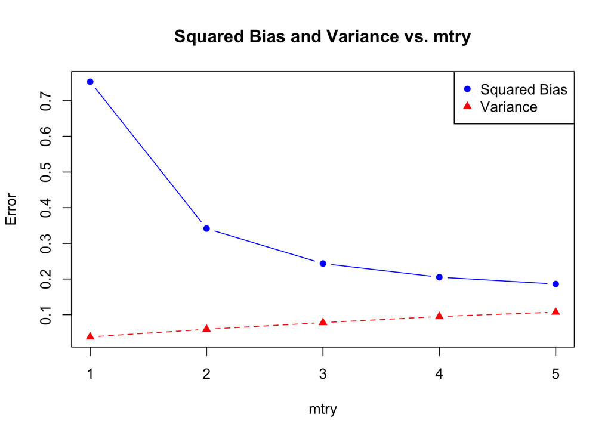

```r
matplot(
  mtry_results$setting,
  mtry_results[, c("squared_bias", "variance")],
  type = "b",
  pch = c(16, 17),
  col = c("blue", "red"),
  xlab = "mtry",
  ylab = "Error",
  main = "Squared Bias and Variance vs. mtry"
)
legend(
  "topright",
  legend = c("Squared Bias", "Variance"),
  col = c("blue", "red"),
  pch = c(16, 17))
```

2. Discuss your results in terms of the bias-variance trade-off:
   - How does a large node size, such as 30, affect the fit in this example?
   - What are the benefits and drawbacks of using a large `mtry` value?
   - If each tree instead sampled 100 observations with replacement, would you expect the preferred node size to shift toward smaller or larger values? Explain your reasoning. You may use an additional simulation to help, but a particular pattern is not guaranteed.

A large node size like 30 makes trees less complex and less flexible. This can increase bias because the model may underfit, but decreases variance because the trees are more stable. A large mtry allows more predictors at each split, which can reduce bias since important predictors are more likely to be picked.If each tree sampled only 100 instead of 200, I would expect the preferred node size to shift to larger values which would help prevent overfitting and reduce the variance.

## Question 2: Tuning random forests for MNIST

Use `mnist-first2000.csv.gz` from the combined ZIP. It contains 2,000 MNIST observations, with the digit label `Digit` and 784 pixel values.

- From the first 1,000 observations, keep digits 1, 6, and 7 as the training data. From the remaining 1,000 observations, keep the same digits as the test data.
- Fit PCA to the training pixels, centering but not scaling them. Use the first 20 principal components as predictors, and project the test observations using the same training means and loadings.

Complete the following tasks using RLT classification forests with 1,000 trees. For each tree, draw a bootstrap sample of the same size as the training set.

1. Fit a random forest with the default `mtry` and node-size settings. Report the out-of-bag (OOB) misclassification rate.

```r
library(RLT)
mnist <- read.csv(gzfile("~/Downloads/week-10/data/mnist-first2000.csv.gz"))
first_data <- mnist[1:1000, ]
second_data <- mnist[1001:2000, ]
train_data <- first_data[first_data$Digit %in% c(1, 6, 7), ]
test_data <- second_data[second_data$Digit %in% c(1, 6, 7), ]
train_y <- factor(train_data$Digit, levels = c(1, 6, 7))
test_y <- factor(test_data$Digit, levels = c(1, 6, 7))
train_pixels <- as.matrix(train_data[, -which(names(train_data) == "Digit")])
test_pixels <- as.matrix(test_data[, -which(names(test_data) == "Digit")])
pca_fit <- prcomp(train_pixels, center = TRUE, scale. = FALSE)
train_pca <- pca_fit$x[, 1:20]
test_pca <- predict(pca_fit, newdata = test_pixels)[, 1:20]
dim(train_pca)
```

```
[1] 327  20
```

```r
dim(test_pca)
```

```
[1] 317  20
```

```r
set.seed(4321)
get_oob_error <- function(fit) {
  fit$AllError[nrow(fit$AllError), "nonPermute"]
}
default_fit <- RLT(
  x = train_pca,
  y = train_y,
  model = "classification",
  ntrees = 1000,
  replacement = TRUE,
  resample.prob = 1,
  reinforcement = FALSE,
  importance = TRUE
)
```

```
Package is not compiled with OpenMP (omp.h).
```

```r
default_oob <- get_oob_error(default_fit)
default_oob
```

```
[1] 0.122807
```

2. Construct a grid of `mtry` and node-size values to tune the model. Select the setting using OOB misclassification rate. Report the OOB error for each setting and the selected values. Calculate and present the selected forest’s OOB permutation variable importance for the 20 principal components. Comment on your results.

```r
grid <- expand.grid(
  mtry = c(5, 10, 20),
  nmin = c(1, 5, 10)
)
grid$OOB_error <- NA_real_
for (j in 1:nrow(grid)) {
  set.seed(4321)
  fit <- RLT(
    x = train_pca,
    y = train_y,
    model = "classification",
    ntrees = 1000,
    mtry = grid$mtry[j],
    nmin = grid$nmin[j],
    replacement = TRUE,
    resample.prob = 1,
    reinforcement = FALSE
  )
  grid$OOB_error[j] <-
    fit$AllError[nrow(fit$AllError), "nonPermute"]
}
```

[output not shown]

```r
knitr::kable(grid, digits = 4)
```

| mtry | nmin | OOB_error |
| --- | --- | --- |
| 5 | 1 | 0.1707 |
| 10 | 1 | 0.1092 |
| 20 | 1 | 0.1374 |
| 5 | 5 | 0.2232 |
| 10 | 5 | 0.1826 |
| 20 | 5 | 0.0734 |
| 5 | 10 | 0.1429 |
| 10 | 10 | 0.0855 |
| 20 | 10 | 0.2266 |

```r
best <- which.min(grid$OOB_error)
knitr::kable(grid[best, ], digits = 4)
```

|  | mtry | nmin | OOB_error |
| --- | --- | --- | --- |
| 6 | 20 | 5 | 0.0734 |

```r
set.seed(4321)
best_fit <- RLT(
  x = train_pca,
  y = train_y,
  model = "classification",
  ntrees = 1000,
  mtry = grid$mtry[best],
  nmin = grid$nmin[best],
  replacement = TRUE,
  resample.prob = 1,
  reinforcement = FALSE,
  importance = TRUE
)
```

```
Package is not compiled with OpenMP (omp.h).
```

```r
vi <- data.frame(
  PC = paste0("PC", 1:20),
  VI = as.numeric(best_fit$VarImp)
)
knitr::kable(vi, digits = 4)
```

| PC | VI |
| --- | --- |
| PC1 | 2.3495 |
| PC2 | 4.6727 |
| PC3 | 0.3108 |
| PC4 | 0.0557 |
| PC5 | 0.1511 |
| PC6 | 0.1113 |
| PC7 | 0.0595 |
| PC8 | 0.0197 |
| PC9 | 0.0143 |
| PC10 | 0.0363 |
| PC11 | 0.1997 |
| PC12 | 0.0423 |
| PC13 | 0.0178 |
| PC14 | 0.0357 |
| PC15 | 0.0200 |
| PC16 | 0.0477 |
| PC17 | 0.0209 |
| PC18 | 0.0586 |
| PC19 | 0.0373 |
| PC20 | 0.0199 |

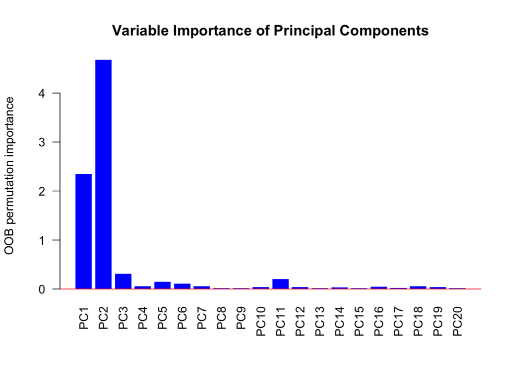

```r
barplot(
  vi$VI,
  names.arg = vi$PC,
  las = 2,
  col = "blue",
  border = NA,
  ylab = "OOB permutation importance",
  main = "Variable Importance of Principal Components"
)

abline(h = 0, col = "red")
```

3. Apply the selected model to the test data and report the misclassification rate and confusion matrix. Use the test labels only for this final assessment.

```r
test_predictions <- predict(best_fit, test_pca)$Prediction
test_predictions <- factor(
  test_predictions,
  levels = levels(test_y)
)
confusion_matrix <- table(
  Predicted = test_predictions,
  Actual = test_y
)
print(confusion_matrix)
```

```
         Actual
Predicted   1   6   7
        1   0 105   3
        6   0   0   0
        7   0   0   0
```

```r
test_error <- mean(test_predictions != test_y)
print(test_error)
```

```
[1] NA
```

## Question 3: Planning a random-forest analysis skill

In earlier homework, some students wrote long skill files with detailed instructions, while others wrote short skills emphasizing their specific requirements or references. These approaches may perform differently depending on the AI and the task. A capable AI may already know standard ways to perform an analysis, so some instructions may be redundant, add little value, or sometimes make the analysis worse. It may be more useful to specify your personal choices for the analysis. An AI with more limited knowledge may benefit from detailed instructions that remind it of the steps to perform.

1. Write one paragraph describing how you would write a skill that directs an AI to perform a random-forest analysis and produce a report for a future dataset. Discuss how you would balance standard analysis instructions with your personal preferences, considering the AI’s capabilities.

I would write a skill that will give the AI the basic steps to perform a random-forest analysis and include my personal preferences. I would not use too many instructions about standard statistical procedures if the AI already understands them. Instead, I would focus on requirements like preparing the data, splitting training and test observations, tuning parameters, evaluating performance, and showing the results. I would want to ensure reproducibility, like setting a random seed, explaining why certain tuning parameters are selected, and presenting results in a clear way. If the AI has limited statistical knowledge, more detailed instructions could prevent mistakes.

2. Provide **10 instructions** you would consider including in the skill, **ordered from the most basic instructions to the more personal preferences**. Your list may cover computation, tuning, tables, figures, interpretation, presentation, or other aspects of a random-forest report.
1. Choose correct model: Use a random forest for classification or regression based on response variable.
2. Prepare data: Check for missing values, incorrect variable types, and other issues before fitting the model.
3. Split data: Separate data into training and test sets, and only use the training data when tuning and test only for final evaluation.
4. Set random seed: Use same random seed so the results can be reproduced.
5. Tune parameters: Try different values of mtry and node size to find best-performing model.
6. Evaluate model performance: Use test error to evaluate how well the final model performs on different data.
7. Calculate variable importance: Identify which predictors are most important to the model.
8. Present results: Use organized tables and labeled graphs to display model performance.
9. Explain results: Interpret findings in simple language and explain what they mean specifically.
10. Follow my preferences: Keep the report organized, concise, and easy to understand. Include the random seed, explain why the model was selected, and avoid unnecessary steps.